# Ciencia de Datos para Economistas

Clase 11: Gráficos Exploratorios (GE)

Autor/a

Afiliación

M.Sc. José Miguel Avendaño I.

Universidad Central de Venezuela- Escuela de Economía. 2025-1

Fecha de publicación

30 de abril de 2025

## Gráficos Exploratorios (GE)

- Comprender características que presentan los datos
- Encontrar patrones presentes o implícitos
- Evaluar posibles estrategias de modelización
- Depurar el análisis
- Comunicar los resultados del proceso de obtención-levantamiento de los datos

## Características de los GE

- Se hacen rápidamente
- Se hace un gran número
- El objetivo es la comprensión personal
- Los ejes/leyendas se limpian generalmente (más tarde)
- El color/tamaño se utilizan principalmente como información

## Características de los GE- 2

- Los gráficos exploratorios son «rápidos y sucios».
- Permiten resumir los datos (normalmente de forma gráfica) y resaltar las características generales.
- Explorar preguntas e hipótesis básicas (y quizás descartarlas)
- Sugieren estrategias de modelización para el «siguiente paso»

## NOTA:

El contenido de las tres anteriores láminas se basa en la presentación “Exploratory Graphs” del Prof. Roger Peng, complementada por su libro “Exploratory Data Analysis with R” disponible en el [enlace](https://bookdown.org/rdpeng/exdata/).

## Sumarios en una Dimensión

- Tablas sumario: `table` , `summary`
- Gráficos:
  - Boxplot - Diagrama de Caja
  - Histograms - Histogramas
  - Density Plot - Gráfico de Densidad
  - Barplot - Diagrama/gráfico de Barras
  - ScatterPlots (bidimensional) - Diagrama de Dispersión

## Conjuntos de Datos a Usar 1

#### Gapminder

```r
head(gapminder)
```

```
# A tibble: 6 × 6
  country     continent  year lifeExp      pop gdpPercap
  <fct>       <fct>     <int>   <dbl>    <int>     <dbl>
1 Afghanistan Asia       1952    28.8  8425333      779.
2 Afghanistan Asia       1957    30.3  9240934      821.
3 Afghanistan Asia       1962    32.0 10267083      853.
4 Afghanistan Asia       1967    34.0 11537966      836.
5 Afghanistan Asia       1972    36.1 13079460      740.
6 Afghanistan Asia       1977    38.4 14880372      786.
```

## Conjuntos de Datos a Usar 2

#### Gapminder 2007

```r
gapminder_2007 <- gapminder%>%
  filter(year==2007)
```

```r
head(gapminder_2007)
```

```
# A tibble: 6 × 6
  country     continent  year lifeExp      pop gdpPercap
  <fct>       <fct>     <int>   <dbl>    <int>     <dbl>
1 Afghanistan Asia       2007    43.8 31889923      975.
2 Albania     Europe     2007    76.4  3600523     5937.
3 Algeria     Africa     2007    72.3 33333216     6223.
4 Angola      Africa     2007    42.7 12420476     4797.
5 Argentina   Americas   2007    75.3 40301927    12779.
6 Australia   Oceania    2007    81.2 20434176    34435.
```

## Conjuntos de Datos a Usar 3

#### Gapminder África y Europa

```r
gapminder_afeu <- gapminder%>%
  filter(continent %in% c('Africa','Europe'))%>%
  mutate(continent= as.character(continent))
```

```r
head(gapminder_afeu)
```

```
# A tibble: 6 × 6
  country continent  year lifeExp     pop gdpPercap
  <fct>   <chr>     <int>   <dbl>   <int>     <dbl>
1 Albania Europe     1952    55.2 1282697     1601.
2 Albania Europe     1957    59.3 1476505     1942.
3 Albania Europe     1962    64.8 1728137     2313.
4 Albania Europe     1967    66.2 1984060     2760.
5 Albania Europe     1972    67.7 2263554     3313.
6 Albania Europe     1977    68.9 2509048     3533.
```

## Conjuntos de Datos a Usar 4

#### Gapminder África y Europa 2007

```r
gapminder_2007_afeu <- gapminder_2007%>%
  filter(continent %in% c('Africa','Europe'))%>%
  mutate(continent= as.character(continent))
```

```r
head(gapminder_2007_afeu)
```

```
# A tibble: 6 × 6
  country continent  year lifeExp      pop gdpPercap
  <fct>   <chr>     <int>   <dbl>    <int>     <dbl>
1 Albania Europe     2007    76.4  3600523     5937.
2 Algeria Africa     2007    72.3 33333216     6223.
3 Angola  Africa     2007    42.7 12420476     4797.
4 Austria Europe     2007    79.8  8199783    36126.
5 Belgium Europe     2007    79.4 10392226    33693.
6 Benin   Africa     2007    56.7  8078314     1441.
```

## Tablas Sumario

```r
summary(gapminder_2007$lifeExp)
```

```
   Min. 1st Qu.  Median    Mean 3rd Qu.    Max.
  39.61   57.16   71.94   67.01   76.41   82.60
```

```r
#
#
#
table(gapminder_2007$continent)
```

```
  Africa Americas     Asia   Europe  Oceania
      52       25       33       30        2
```

## Opciones para Graficación - Sistemas

- Base: hoy
- GGplot: próxima clase

## Diagrama de Caja y Bigotes (Boxplot)

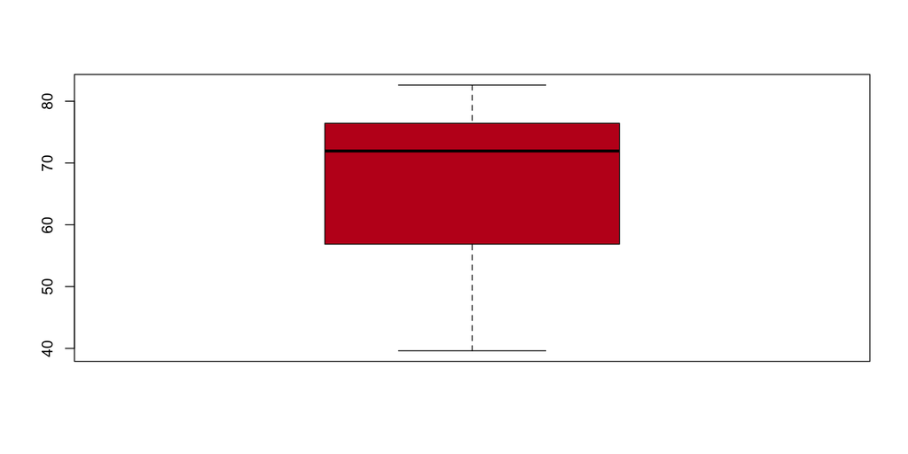

```r
boxplot(gapminder_2007$lifeExp,
        col = "#c1121f")
```

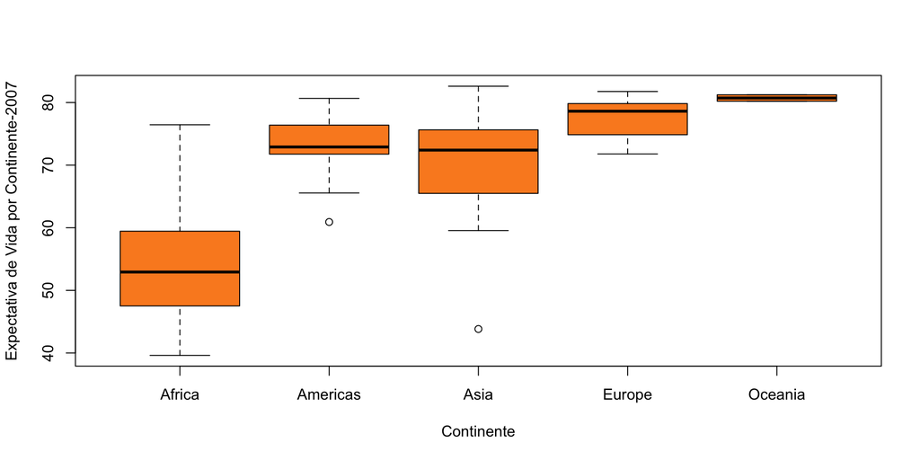

```r
boxplot(lifeExp ~ continent,
        data = gapminder_2007,
        col = "#fb8b24",
        xlab='Continente',
        ylab='Expectativa de Vida por Continente-2007')
```

## Diagrama de Caja - Concepto

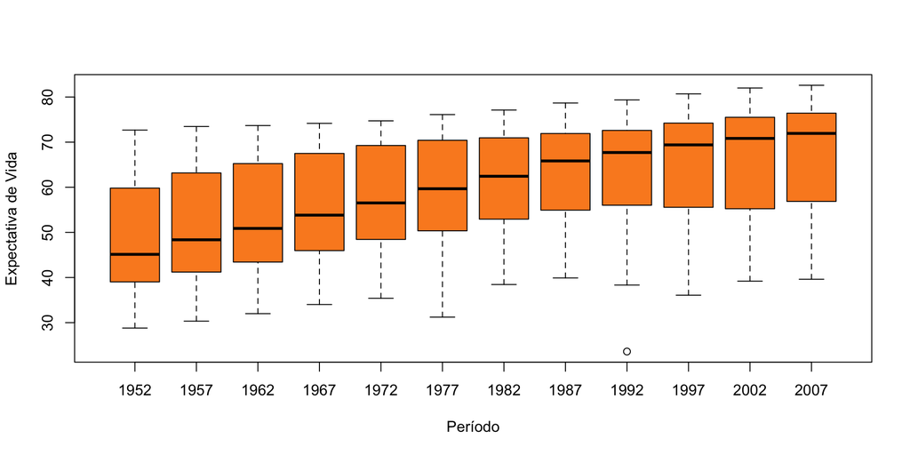

```r
boxplot(lifeExp ~ year,
        data = gapminder,
        col = "#fb8b24",
        xlab='Período',
        ylab='Expectativa de Vida')
```

Es un gráfico que resume las características principales de un conjunto de datos numéricos, como la mediana, el rango intercuartil (IQR) (25%, 50% y 75%) y los valores atípicos.

## Diagrama de Caja - Casos de Uso - 1

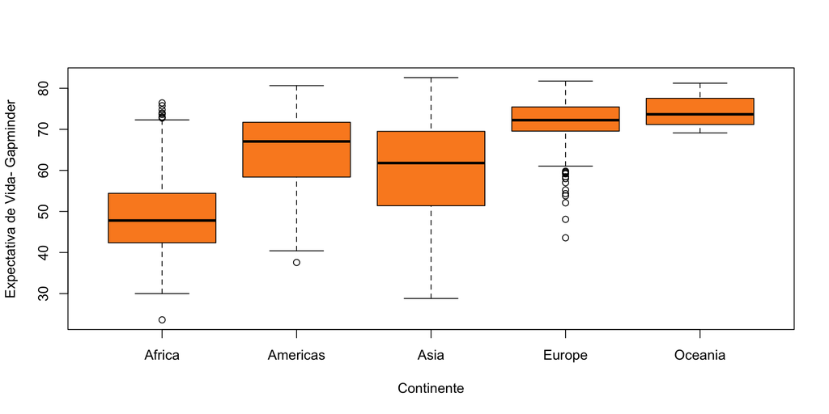

- Comparar distribuciones de diferentes grupos.

## Diagrama de Caja - Casos de Uso - 2

- Identificar *outliers* (valores atípicos).
- Analizar la centralización, dispersión y simetría de los datos.

[figure not shown]

## Diagrama de Caja - Casos de Uso - 3

- Detectar diferencias significativas entre grupos.

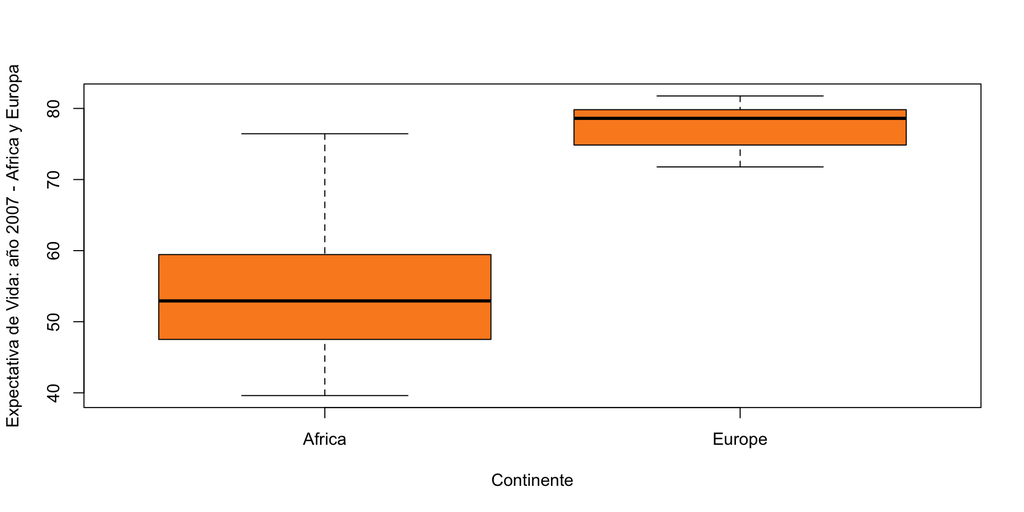

## Histogramas

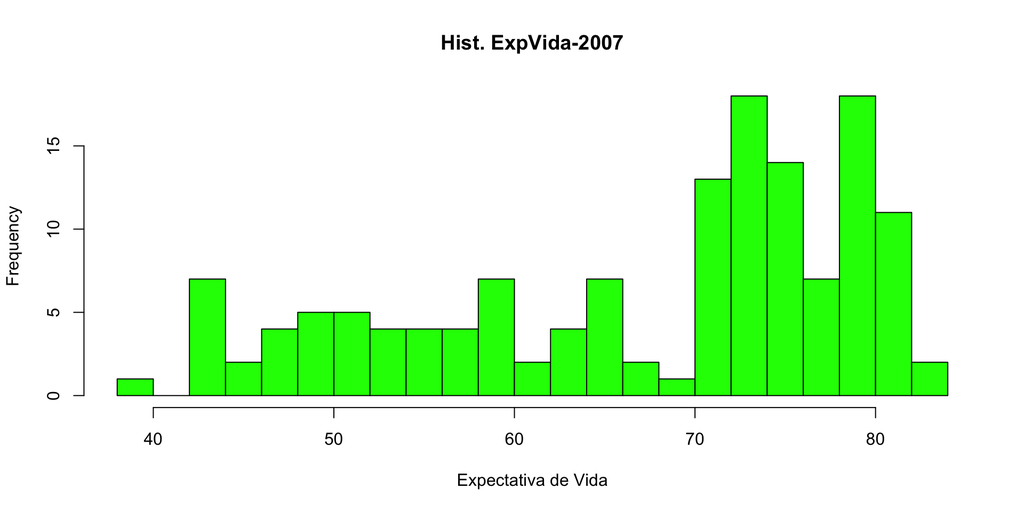

```r
hist(main = 'Hist. ExpVida-2007',
     gapminder_2007$lifeExp,
     col = "green",
     xlab='Expectativa de Vida',
     breaks = 20)
```

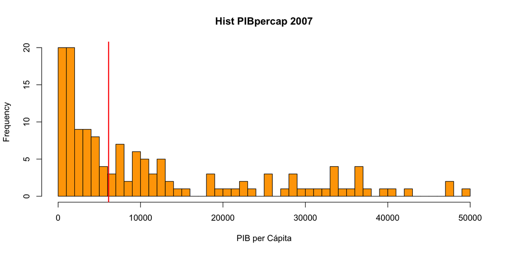

```r
hist(main = 'Hist PIBpercap 2007',
     gapminder_2007$gdpPercap,
     col = "orange",
     xlab='PIB per Cápita',
     breaks = 50)

abline(v = median(gapminder_2007$gdpPercap),
       col = "red",
       lwd = 2)
```

## Histogramas- Concepto

Muestra la distribución de frecuencias de un conjunto de datos numéricos. Se divide el rango de datos en intervalos (bins) y se representa la frecuencia de los valores que caen dentro de cada intervalo como barras.

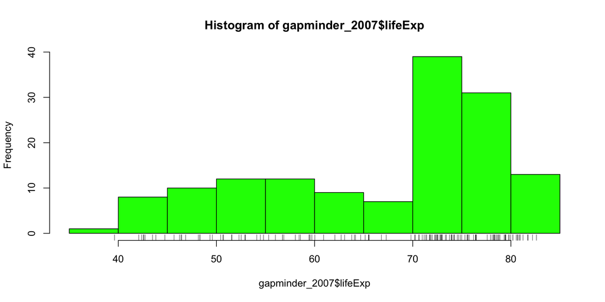

```r
hist(gapminder_2007$lifeExp,
     col = "green")

rug(gapminder_2007$lifeExp)
```

## Histogramas- Casos de Uso

- Visualizar la forma y simetría de una distribución.
- Identificar picos, modas y áreas con baja frecuencia.
- Comparar distribuciones entre diferentes grupos.
- Detectar valores atípicos.

## Múltiples Histogramas

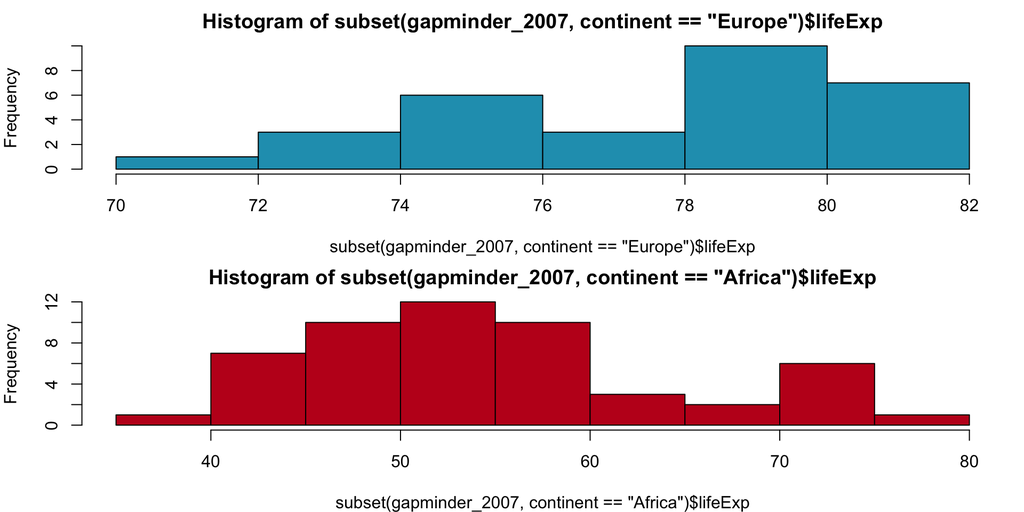

```r
par(mfrow = c(2, 1),
    mar = c(4, 4, 2, 1))

hist(subset(gapminder_2007,
            continent == "Europe")$lifeExp,
     col ="#219ebc" )

hist(subset(gapminder_2007,
            continent == "Africa")$lifeExp,
     col = "#c1121f")
```

## Gráfico de Densidad (Density Plot)

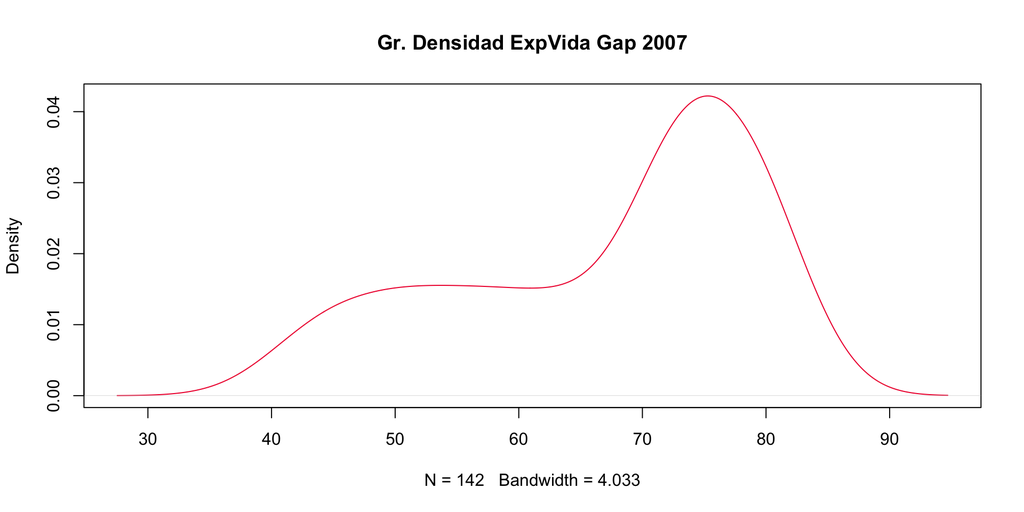

```r
dens <- density(gapminder_2007$lifeExp)
# plot density
plot(dens,
     col = "#ef233c",
     main = "Gr. Densidad ExpVida Gap 2007")
```

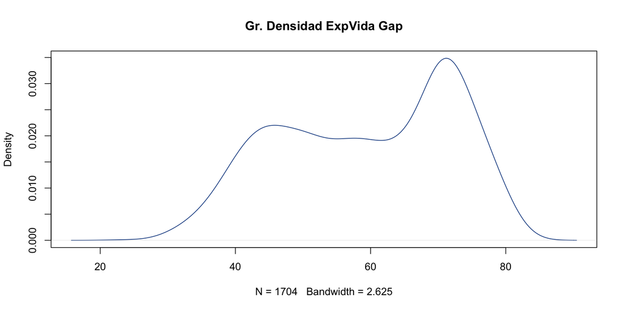

```r
dens1 <- density(gapminder$lifeExp)
# plot density
plot(dens1,
     col = "#023e8a",
     main = "Gr. Densidad ExpVida Gap")
```

## Gráfico de Densidad- Concepto

Gráfico que muestra la densidad de probabilidad de un conjunto de datos numéricos. Se utiliza una curva suave para representar la distribución, donde la altura de la curva en un punto indica la densidad de los valores cercanos a ese punto.

## Gráfico de Densidad- Casos de uso

- Visualizar la forma y simetría de una distribución de manera más continua que el histograma.
- Comparar distribuciones entre diferentes grupos.
- Identificar picos, modas y áreas con baja densidad.

## Diagrama de Barras (Barplot)

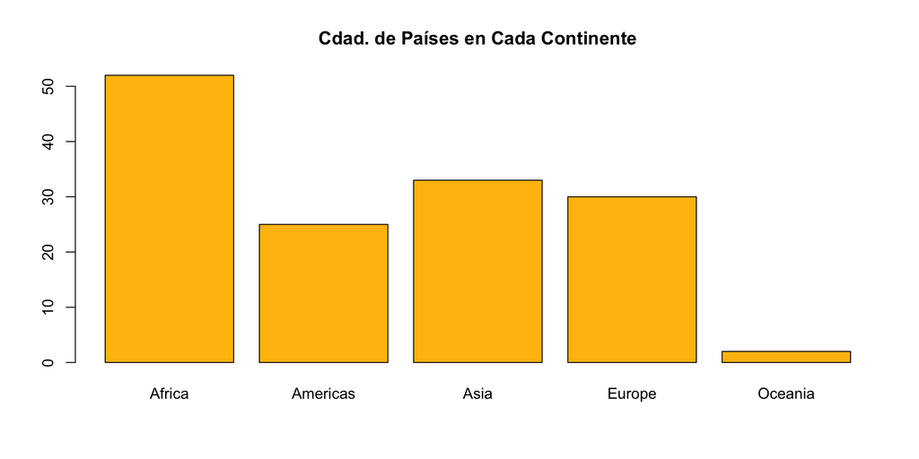

```r
barplot(table(gapminder_2007$continent),
        col = "#ffbe0b",
        main = "Cdad. de Países en Cada Continente")
```

## Diagrama de Barras- Concepto

Es un gráfico que utiliza barras para representar la frecuencia o magnitud de variables categóricas-discretas. La altura de cada barra corresponde a la frecuencia o magnitud de la categoría correspondiente.

## Diagrama de Barras- Casos de uso

- Comparar frecuencias o magnitudes entre diferentes categorías.
- Mostrar tendencias a lo largo del tiempo.
- Representar datos nominales o ordinales.

## Diagrama de Dispersión (Scatter Plot)

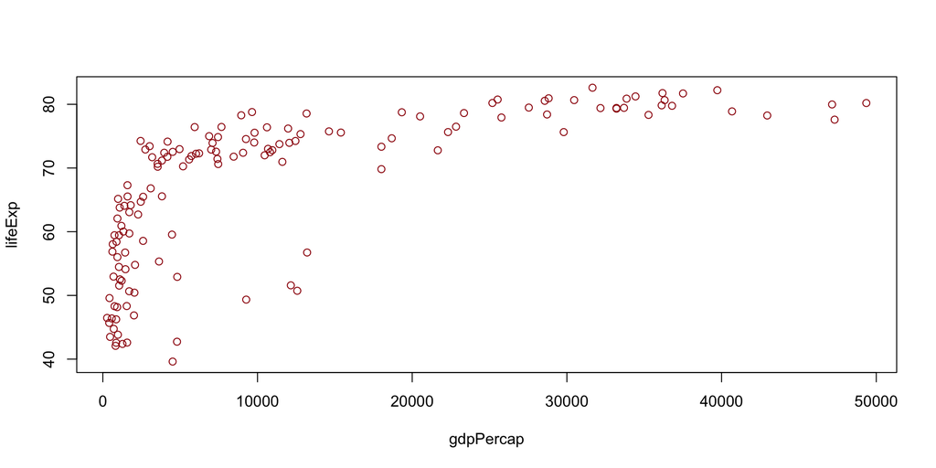

```r
with(gapminder_2007,
     plot(gdpPercap,
          lifeExp,
          col= "#9d0208"))
```

## Diagrama de Dispersión- Concepto

Gráfico que muestra la relación entre dos variables numéricas. Cada punto en el gráfico representa una observación, con su posición determinada por los valores de las dos variables.

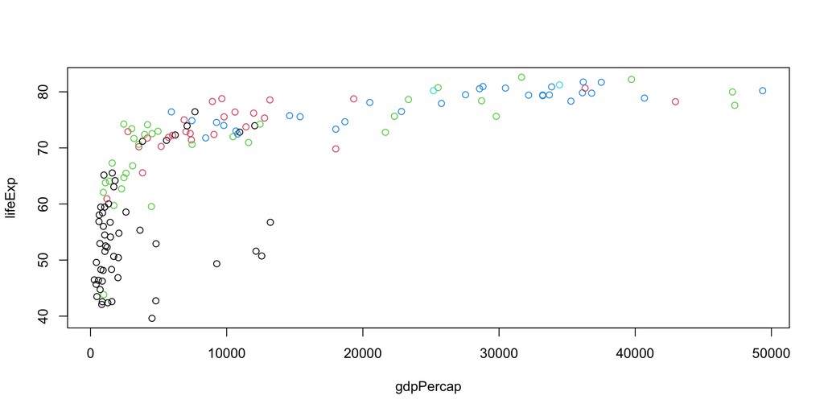

```r
with(gapminder_2007,
     plot(gdpPercap,
           lifeExp,
          col= continent))
```

## Diagrama de Dispersión- Casos de uso

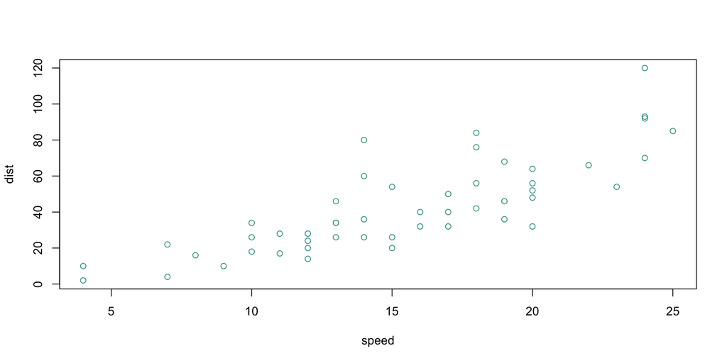

```r
with(cars,
     plot( speed,
           dist,
          col= "#2a9d8f"))
```

- Visualizar la correlación entre dos variables.
- Identificar tendencias y patrones en los datos.
- Detectar *outliers* (valores atípicos).
- Analizar la relación lineal o no lineal entre variables.

# Consideraciones Sobre Sistema Base

## Parámetros Comunes Sistema Base

- pch: el símbolo de trazado (por defecto es círculo abierto)
- lty: el tipo de línea (por defecto es línea continua), puede ser discontinua, punteada, etc.
- lwd: la anchura de la línea, especificada como un múltiplo entero col: el color de trazado, especificado como número, cadena o código hexadecimal;

## Parámetros Comunes Sistema Base -2

- col: el color de trazado, especificado como número, cadena o código hexadecimal; la función colors() le proporciona un vector de colores por nombre.
- xlab: cadena de caracteres para la etiqueta del eje x
- ylab: cadena de caracteres para la etiqueta del eje y

## Parámetros Globales Sistema Base

La función par() se utiliza para especificar parámetros gráficos globales que afectan a todos los gráficos de una sesión de R. Estos parámetros pueden anularse cuando se especifican como argumentos de funciones de trazado específicas.

- las: la orientación de las etiquetas de los ejes en el gráfico
- bg: color de fondo
- mar: el tamaño del margen

## Ejemplo de Construcción de Gráfico en Base

**código**

```r
with(airquality,
     plot(Wind,
          Ozone,
          main = "Ozono y Viento en ciudad de New York ",
          # type = "n",
          col='orange'))

with(subset(airquality,
            Month == 5),
     points(Wind,
            Ozone,
            col = "blue"))

with(subset(airquality,
            Month != 5),
     points(Wind,
            Ozone,
            col = "#fb5607"))

legend("topright",
       pch = 1,
       col = c("blue",
               "#fb5607"),
       legend = c("Mayo", "Otros Meses"))
```

**gráfico**

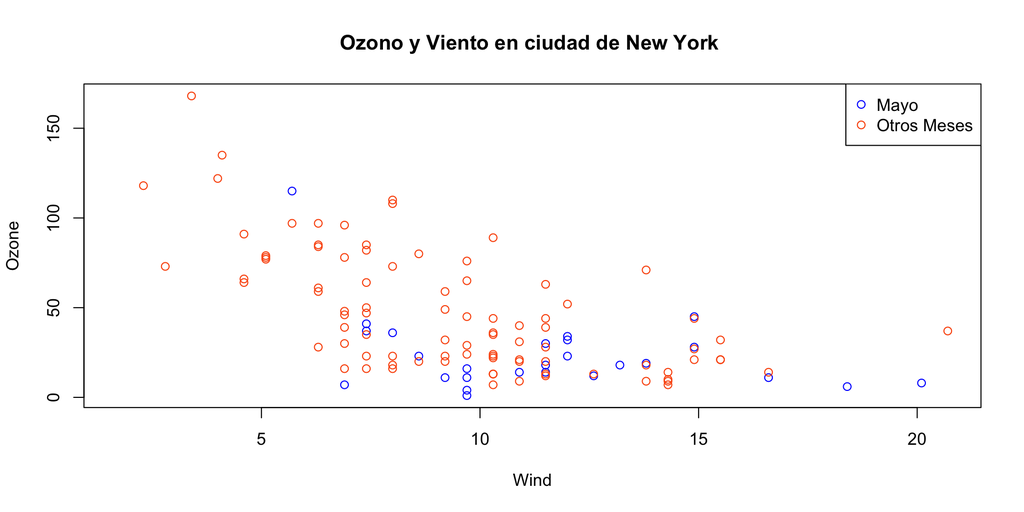

## Resumen GE:

- Los gráficos exploratorios son «rápidos y sucios».
- Permiten resumir los datos (normalmente de forma gráfica) y resaltar las características generales.
- Explorar preguntas e hipótesis básicas (y quizás descartarlas)
- Sugieren estrategias de modelización para el «siguiente paso».